# midterm1 Extra Credit review sheet

*Source file* ⇒ mtreview_ec.Rmd

Lec 4

**Replicator and Sequence functions** These functions are handy for making sequences of numbers.  
Seq is a generalization of “:”  
Seq uses the arguement *by*

```r
1:5
```

```
## [1] 1 2 3 4 5
```

```r
5:1
```

```
## [1] 5 4 3 2 1
```

```r
seq(0,11, by=2)
```

```
## [1]  0  2  4  6  8 10
```

```r
seq(10,0, by=-2)
```

```
## [1] 10  8  6  4  2  0
```

The replicator function uses the argument *times* or *each*

```r
rep(c(0,1), times=5)
```

```
##  [1] 0 1 0 1 0 1 0 1 0 1
```

```r
rep(letters[1:5],each=2)
```

```
##  [1] "a" "a" "b" "b" "c" "c" "d" "d" "e" "e"
```

```r
rep(1:3, each =2, times=3)
```

```
##  [1] 1 1 2 2 3 3 1 1 2 2 3 3 1 1 2 2 3 3
```

lec 7

Volcabulary:

See figure 6.7 page 57

*Frame*= The space for drawing gyphs. Here a rectangular region set by roadways and gdp.  
*Glyph*= A symbol or a marking in a frame . There is one glyph for for each case in the data table. Here points.  
*Aesthetics*= The properties of a glyph. Here x,y, size.  
*Scales and Guides*= Variables of the data table are *mapped* to aesthetics of the glyph. Here, x=roadways, y= gdp, educ= size  
*Facets*= Multiple side by side graphs used to display levels of a categorical variable. Here facets are different ranges of Internet connectivity.  
*Layers*= data from more than one data table are graphed together. Here not layered.

Rarely is a data table *glyph ready*. We usually need to *wrangle* the data. For example say we want to make a bar chart ranking the candidates by how many precincts they are in first place.

```r
#not glyph ready
head(Minneapolis2013)
```

| Precinct | First | Second | Third | Ward |
| --- | --- | --- | --- | --- |
| P-10 | BETSY HODGES | undervote | undervote | W-7 |
| P-06 | BOB FINE | MARK ANDREW | undervote | W-10 |
| P-09 | KURTIS W. HANNA | BOB FINE | MIKE GOULD | W-10 |
| P-05 | BETSY HODGES | DON SAMUELS | undervote | W-13 |
| P-01 | DON SAMUELS | undervote | undervote | W-5 |
| P-04 | undervote | undervote | undervote | W-6 |

```r
FirstPlaceTally <- Minneapolis2013 %>%
  rename(candidate=First) %>%
  group_by(candidate) %>%
  summarise(total=n()) %>%
  arrange( desc(total))

#glyph ready

FirstPlaceTally
```

| candidate | total |
| --- | --- |
| BETSY HODGES | 28935 |
| MARK ANDREW | 19584 |
| DON SAMUELS | 8335 |
| CAM WINTON | 7511 |
| JACKIE CHERRYHOMES | 3524 |
| BOB FINE | 2094 |
| DAN COHEN | 1798 |
| STEPHANIE WOODRUFF | 1010 |
| MARK V ANDERSON | 975 |
| undervote | 834 |
| DOUG MANN | 779 |
| OLE SAVIOR | 693 |
| ALICIA K. BENNETT | 351 |
| JAMES EVERETT | 347 |
| ABDUL M RAHAMAN “THE ROCK” | 338 |
| CAPTAIN JACK SPARROW | 264 |
| TONY LANE | 219 |
| MIKE GOULD | 204 |
| KURTIS W. HANNA | 200 |
| JAYMIE KELLY | 196 |
| CHRISTOPHER CLARK | 188 |
| CHRISTOPHER ROBIN ZIMMERMAN | 170 |
| JEFFREY ALAN WAGNER | 164 |
| TROY BENJEGERDES | 148 |
| NEAL BAXTER | 145 |
| GREGG A. IVERSON | 144 |
| UWI | 117 |
| JOSHUA REA | 108 |
| MERRILL ANDERSON | 108 |
| BILL KAHN | 97 |
| JOHN LESLIE HARTWIG | 97 |
| overvote | 93 |
| EDMUND BERNARD BRUYERE | 70 |
| RAHN V. WORKCUFF | 65 |
| JAMES “JIMMY” L. STROUD, JR. | 64 |
| BOB “AGAIN” CARNEY JR | 56 |
| CYD GORMAN | 39 |
| JOHN CHARLES WILSON | 37 |

1. Find the average of one of the variables.
2. Add a new column that is the ratio between two variables.
3. Sort the cases in descending order of a variable.
4. Create a new data table that includes only those cases that meet a criterion.
5. From a data table with several variables produce an output that has the same cases but only the first two variables.
6. From a data table with a categorical variables and a quantitative variable produce a count for the number of cases for each level of the categorical variable.

solution:

```r
mtcars
```

|  | mpg | cyl | disp |
| --- | --- | --- | --- |
| Mazda RX4 | 21.0 | 6 | 160.0 |
| Mazda RX4 Wag | 21.0 | 6 | 160.0 |
| Datsun 710 | 22.8 | 4 | 108.0 |
| Hornet 4 Drive | 21.4 | 6 | 258.0 |
| Hornet Sportabout | 18.7 | 8 | 360.0 |
| Valiant | 18.1 | 6 | 225.0 |
| Duster 360 | 14.3 | 8 | 360.0 |
| Merc 240D | 24.4 | 4 | 146.7 |
| Merc 230 | 22.8 | 4 | 140.8 |
| Merc 280 | 19.2 | 6 | 167.6 |
| Merc 280C | 17.8 | 6 | 167.6 |
| Merc 450SE | 16.4 | 8 | 275.8 |
| Merc 450SL | 17.3 | 8 | 275.8 |
| Merc 450SLC | 15.2 | 8 | 275.8 |
| Cadillac Fleetwood | 10.4 | 8 | 472.0 |
| Lincoln Continental | 10.4 | 8 | 460.0 |
| Chrysler Imperial | 14.7 | 8 | 440.0 |
| Fiat 128 | 32.4 | 4 | 78.7 |
| Honda Civic | 30.4 | 4 | 75.7 |
| Toyota Corolla | 33.9 | 4 | 71.1 |
| Toyota Corona | 21.5 | 4 | 120.1 |
| Dodge Challenger | 15.5 | 8 | 318.0 |
| AMC Javelin | 15.2 | 8 | 304.0 |
| Camaro Z28 | 13.3 | 8 | 350.0 |
| Pontiac Firebird | 19.2 | 8 | 400.0 |
| Fiat X1-9 | 27.3 | 4 | 79.0 |
| Porsche 914-2 | 26.0 | 4 | 120.3 |
| Lotus Europa | 30.4 | 4 | 95.1 |
| Ford Pantera L | 15.8 | 8 | 351.0 |
| Ferrari Dino | 19.7 | 6 | 145.0 |
| Maserati Bora | 15.0 | 8 | 301.0 |
| Volvo 142E | 21.4 | 4 | 121.0 |

```r
mtcars %>%
  summarise(avg_count=mean(cyl))
```

## avg_count

```
6.1875
```

```r
mtcars %>%
  mutate(ratio=mpg/cyl) %>%
  tail()
```

|  | mpg | cyl | disp | ratio |
| --- | --- | --- | --- | --- |
| 27 | 26.0 | 4 | 120.3 | 6.500000 |
| 28 | 30.4 | 4 | 95.1 | 7.600000 |
| 29 | 15.8 | 8 | 351.0 | 1.975000 |
| 30 | 19.7 | 6 | 145.0 | 3.283333 |
| 31 | 15.0 | 8 | 301.0 | 1.875000 |
| 32 | 21.4 | 4 | 121.0 | 5.350000 |
| c. |  |  |  |  |

```r
mtcars %>%
  arrange(desc(mpg)) %>%
  tail()
```

|  | mpg | cyl | disp |
| --- | --- | --- | --- |
| 27 | 15.0 | 8 | 301 |
| 28 | 14.7 | 8 | 440 |
| 29 | 14.3 | 8 | 360 |
| 30 | 13.3 | 8 | 350 |
| 31 | 10.4 | 8 | 472 |
| 32 | 10.4 | 8 | 460 |
| d. |  |  |  |

```r
mtcars %>%
  filter(mpg >30)
```

| mpg | cyl | disp |
| --- | --- | --- |
| 32.4 | 4 | 78.7 |
| 30.4 | 4 | 75.7 |
| 33.9 | 4 | 71.1 |
| 30.4 | 4 | 95.1 |
| e. |  |  |

```r
mtcars %>%
  select(mpg, cyl) %>%
  tail()
```

|  | mpg | cyl |
| --- | --- | --- |
| Porsche 914-2 | 26.0 | 4 |
| Lotus Europa | 30.4 | 4 |
| Ford Pantera L | 15.8 | 8 |
| Ferrari Dino | 19.7 | 6 |
| Maserati Bora | 15.0 | 8 |
| Volvo 142E | 21.4 | 4 |
| f. |  |  |

```r
BabyNames %>%
  group_by(sex) %>%
  summarise(total=sum(count))
```

| sex | total |
| --- | --- |
| F | 165280729 |
| M | 168137041 |

lec 8

Last class we learned about the data verbs, arrange(), filter(), select(), mutate(), group_by, and summarise().

A few notes:

1. The function sum() takes a vector and adds up the elements.

```r
a <- c(1,2,2,2,3)
sum(a)  # sum of elements of a
```

```
## [1] 10
```

```r
sum(a==2) # number of elements of a that have the value 2
```

```
## [1] 3
```

2. Sum is usefull in summarise(). For example suppose you want to display the number of times the name “Adam” and “John” appears in the BabyNames data table.

```r
BabyNames %>%
  summarise(Adam_sum= sum(name=="Adam"), John_sum= sum(name == "John"))
```

| Adam_sum | John_sum |
| --- | --- |
| 190 | 268 |

3. n() adds up the number of cases. It is usefull inside of summarise(). Lets find the number of boys names in the year 1890

```r
BabyNames %>%
  filter(year==1890, sex=="M") %>%
  summarise( total = n())
```

## total

1161

4. Tally() is another way to add up the number of cases of a data table.

```r
BabyNames %>%
  filter(year==1890, sex=="M") %>%
  tally()   # tally calls the number of cases n
```

## n

1161 It is similar to nrow

```r
BabyNames %>%
  filter(year==1890, sex=="M") %>%
  nrow()
```

```
## [1] 1161
```

lec 10

# Today

1. New printr package for making nice tables
2. More on Joins (Chapter 7)
3. ggplot from DataCamp’s ggplot2 (1) course including wide versus narrow data table format

# 1. printr

```r
head(mtcars)
```

|  | mpg | cyl | disp |
| --- | --- | --- | --- |
| Mazda RX4 | 21.0 | 6 | 160 |
| Mazda RX4 Wag | 21.0 | 6 | 160 |
| Datsun 710 | 22.8 | 4 | 108 |
| Hornet 4 Drive | 21.4 | 6 | 258 |
| Hornet Sportabout | 18.7 | 8 | 360 |
| Valiant | 18.1 | 6 | 225 |

To produce more publication quality tables use the new package printr. It isn’t available yet on the CRAN repository so you have to install it by running the following chunk (you neeed to run it not just Knit HTML).

```r
install.packages(
  'printr',
  type = 'source',
  repos = c('http://yihui.name/xran', 'http://cran.rstudio.com')
)
```

Once you install it you will see prinr in your packages list in rstudio. You only have to do this once.

Next you need to remember to put library(printr) in a chunk in your rmarkdown file.

```r
library(printr)
```

Here is a print out of mtcars now:

```r
head(mtcars)
```

|  | mpg | cyl | disp |
| --- | --- | --- | --- |
| Mazda RX4 | 21.0 | 6 | 160 |
| Mazda RX4 Wag | 21.0 | 6 | 160 |
| Datsun 710 | 22.8 | 4 | 108 |
| Hornet 4 Drive | 21.4 | 6 | 258 |
| Hornet Sportabout | 18.7 | 8 | 360 |
| Valiant | 18.1 | 6 | 225 |

# 2. Joins

Each of the data verbs described until now takes one one data table as an input. Join is different. It’s well named: it brings together two data tables. Once you can join two data tables, you can join any number of data tables by repeated joins. Joining is at the heart of combining data from multiple sources.

It’s conventional to refer to the two tables as the “left” and “right” tables.

To illustrate the differences and similarities between the different kinds of join, suppose you have these two tables:

To illustrate the differences and similarities between the different kinds of join, suppose you have these two tables:

- Left: cases are medical clinics. The variables: `clinicName`, `postalCode`. Each clinic does multiple procedures.

| clinicName | postalCode |
| --- | --- |
| A | 22120 |
| B | 35752 |
| C | 56718 |
| D | 35752 |
| E | 67756 |
| F | 69129 |
| G | 73455 |
| H | 73455 |
| I | 76292 |

- Right: cases are postal codes. Variables reflect the demographics of that postal code: `postalCode`, `over65`, etc.

| over65 | postalCode |
| --- | --- |
| 0.46 | 35752 |
| 0.72 | 22120 |
| 0.93 | 22120 |
| 0.26 | 92332 |
| 0.46 | 84739 |
| 0.94 | 67756 |

Variables that appear in both the left and right tables are called “overlap variables.” The only overlap variable here is `postalCode`.

The overlap variables determine which cases will go into the output table. In this example, there is just one overlap variable: `postalCode`.

The diagram below shows the cases in the left and right tables. The lines show the matches between left and right. The cases connected by a match are the overlap cases; there are five of them in the diagram. Cases without a match also appear in both the left and right tables.

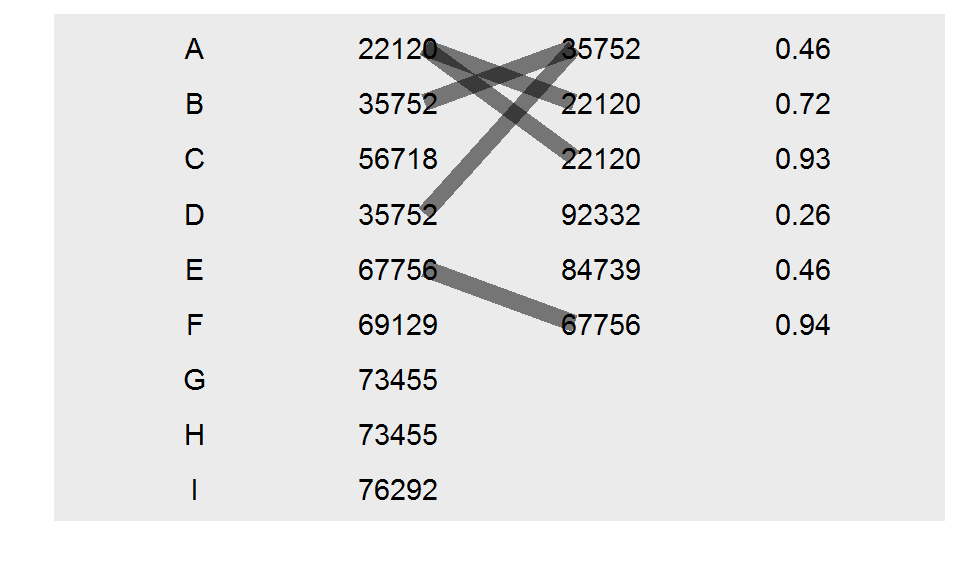

Note that there are three different kinds of cases here:

1. The matching cases that are in both the left and right. These come as pairs: the cases connected by a line in the diagram.
2. Non-matching ones in the left.
3. Non-matching ones in the right.

There are different types of join. The type of join specifies whether you want to include in the output the matching cases, the matching pairs, or the non-matching cases.

#### Inner Join

An *inner join* gives the matching pairs. Note that clinic A, which had two matches in the right table, appears twice, once for each matching pair in which clinic A is involved.

```r
LL %>% inner_join(RR, by=c("postalCode"="postalCode"))
```

| clinicName | postalCode | over65 |
| --- | --- | --- |
| A | 22120 | 0.72 |
| A | 22120 | 0.93 |
| B | 35752 | 0.46 |
| D | 35752 | 0.46 |
| E | 67756 | 0.94 |

#### Outer Join

An *outer join* can include cases where there is no match. You might want to include the unmatched cases from the left table, from the right table, or from both tables.

##### Unmatched cases from the left table

```r
LL %>% left_join( RR)
```

| clinicName | postalCode | over65 |
| --- | --- | --- |
| A | 22120 | 0.72 |
| A | 22120 | 0.93 |
| B | 35752 | 0.46 |
| C | 56718 | NA |
| D | 35752 | 0.46 |
| E | 67756 | 0.94 |
| F | 69129 | NA |
| G | 73455 | NA |
| H | 73455 | NA |
| I | 76292 | NA |

##### Unmatched cases from the right table

```r
LL %>%  right_join(RR)
```

| clinicName | postalCode | over65 |
| --- | --- | --- |
| B | 35752 | 0.46 |
| D | 35752 | 0.46 |
| A | 22120 | 0.72 |
| A | 22120 | 0.93 |
| NA | 92332 | 0.26 |
| NA | 84739 | 0.46 |
| E | 67756 | 0.94 |

##### Unmatched cases from both tables

```r
LL %>% full_join(RR)
```

| clinicName | postalCode | over65 |
| --- | --- | --- |
| A | 22120 | 0.72 |
| A | 22120 | 0.93 |
| B | 35752 | 0.46 |
| C | 56718 | NA |
| D | 35752 | 0.46 |
| E | 67756 | 0.94 |
| F | 69129 | NA |
| G | 73455 | NA |
| H | 73455 | NA |
| I | 76292 | NA |
| NA | 92332 | 0.26 |
| NA | 84739 | 0.46 |

### Task For You:

Here is a left and right data table:

```r
Left <- CountryCentroids %>% select(name, iso_a3) %>% tail()
Left
```

|  | name | iso_a3 |
| --- | --- | --- |
| 236 | Vietnam | VNM |
| 237 | W. Sahara | ESH |
| 238 | Wallis and Futuna Is. | WLF |
| 239 | Yemen | YEM |
| 240 | Zambia | ZMB |
| 241 | Zimbabwe | ZWE |

```r
Right <-  CountryData %>% select(country,life, infant) %>% tail()
Right
```

|  | country | life | infant |
| --- | --- | --- | --- |
| 251 | Wallis and Futuna | 79.42 | 4.49 |
| 252 | West Bank | 75.69 | 13.49 |
| 253 | Western Sahara | 62.27 | 56.09 |
| 254 | Yemen | 64.83 | 50.41 |
| 255 | Zambia | 51.83 | 66.62 |
| 256 | Zimbabwe | 55.68 | 26.55 |

Make the following join:

| name | iso_a3 | life | infant |
| --- | --- | --- | --- |
| Yemen | YEM | 64.83 | 50.41 |
| Zambia | ZMB | 51.83 | 66.62 |
| Zimbabwe | ZWE | 55.68 | 26.55 |

Lecture 11

# 1. The data verb: separate() (not in book)

You can separate one column into multiple columns using the date verb separate()

## Example

```r
iris_narrow %>% head()
```

| Species | key | Value |
| --- | --- | --- |
| setosa | Sepal.Length | 5.1 |
| setosa | Sepal.Length | 4.9 |
| setosa | Sepal.Length | 4.7 |
| setosa | Sepal.Length | 4.6 |
| setosa | Sepal.Length | 5.0 |
| setosa | Sepal.Length | 5.4 |

```r
iris_narrow %>% separate(key, into=c("Part", "Measure"), sep="\\.")
```

| Species | Part | Measure | Value |
| --- | --- | --- | --- |
| setosa | Sepal | Length | 5.1 |
| setosa | Sepal | Length | 4.9 |
| setosa | Sepal | Length | 4.7 |
| setosa | Sepal | Length | 4.6 |
| setosa | Sepal | Length | 5.0 |
| setosa | Sepal | Length | 5.4 |

### Task for you:

Here is a data frame with a column `x` we wish to split into three columns

```r
df <- data.frame(x=c("1-2-3", "a-b-c"),  y=c(1,2))
df
```

| x | y |
| --- | --- |
| 1-2-3 | 1 |
| a-b-c | 2 |

Do this using into=c(“a”,“b”,“c”) and sep=“-”

```r
df %>% separate(x,into=c("a","b","c"), sep="-")
```

| a | b | c | y |
| --- | --- | --- | --- |
| 1 | 2 | 3 | 1 |
| a | b | c | 2 |

# 2. Wide versus Narrow data tables (chapter 11)

A data table can be presented in wide or narrow format. Each have their own advantatges.

Wide format is easier to get the difference of before and after of a test for each patient.

```r
BP_wide
```

| subject | before | after |
| --- | --- | --- |
| BHO | 120 | 160 |
| GWB | 115 | 135 |
| WJC | 105 | 145 |

Narrow format is easier to include additional cases of a patient if they are tested on different days. A narrow format is sometimes called a tidy data table.

```r
BP_narrow
```

| subject | when | sbp |
| --- | --- | --- |
| BHO | before | 160 |
| GWB | before | 115 |
| WJC | after | 145 |
| GWB | after | 135 |
| WJC | before | 105 |
| BHO | after | 160 |

The data verbs ’spread()`and`gather()` convert between these formats.

### `gather()` transforms *BP_wide* into *BP_narrow*

The *key* variable is the name of the new variable in the narrow format that is *gathered*.

```r
BP_narrow1 <-  BP_wide %>%
  gather(key= when, value = sbp, before, after)
BP_narrow1
```

| subject | when | sbp |
| --- | --- | --- |
| BHO | before | 120 |
| GWB | before | 115 |
| WJC | before | 105 |
| BHO | after | 160 |
| GWB | after | 135 |
| WJC | after | 145 |

### `spread()` transforms *BP_narrow* into *BP_wide*

The *key* variable is the name of the original variable in the narrow format that is *spread*.

```r
BP_wide1 <-  BP_narrow %>%
  spread(key= when, value = sbp)
BP_wide1
```

| subject | after | before |
| --- | --- | --- |
| BHO | 160 | 160 |
| GWB | 135 | 115 |
| WJC | 145 | 105 |

### task for you

Is the following data set narrow or wide? Convert it to the other data table format.

```r
Baby_narrow <- BabyNames %>%
  filter(name == "Sue") %>%
  group_by(name,sex) %>%
  summarise(total=sum(count))
Baby_wide <- Baby_narrow %>% spread(key=sex, value= total )
Baby_wide
```

| name | F | M |
| --- | --- | --- |
| Sue | 144410 | 519 |

```r
Baby_wide %>% gather(key=sex, value=value, F, M)
```

| name | sex | value |
| --- | --- | --- |
| Sue | F | 144410 |
| Sue | M | 519 |

Note that a narrow table is tidy as we defined in the first day of class. There are no column names as there are in the wide format.

### example

Lets examine the wide iris data table:

```r
head(iris)
```

| Sepal.Length | Sepal.Width | Petal.Length | Petal.Width | Species |
| --- | --- | --- | --- | --- |
| 5.1 | 3.5 | 1.4 | 0.2 | setosa |
| 4.9 | 3.0 | 1.4 | 0.2 | setosa |
| 4.7 | 3.2 | 1.3 | 0.2 | setosa |
| 4.6 | 3.1 | 1.5 | 0.2 | setosa |
| 5.0 | 3.6 | 1.4 | 0.2 | setosa |
| 5.4 | 3.9 | 1.7 | 0.4 | setosa |

Suppose you want to make the following plot:

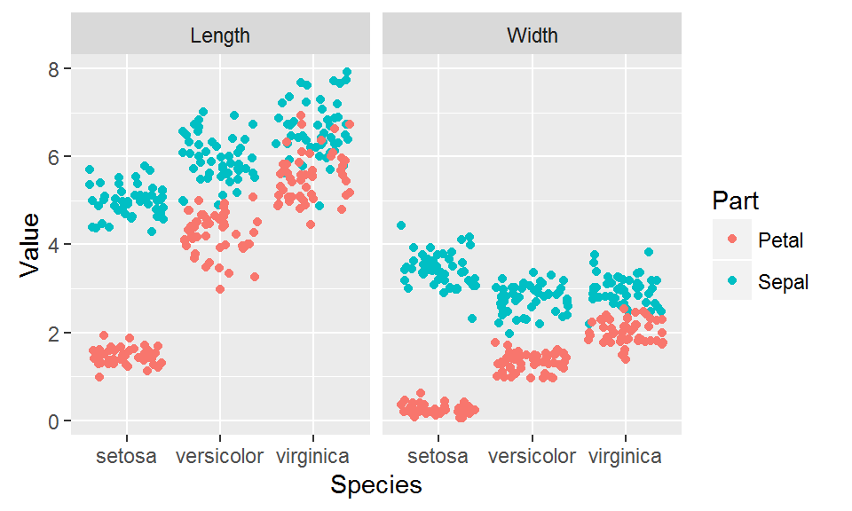

The data table `iris` isn’t gyph ready. Here is the glyph ready table:

| Species | Part | Measure | Value |
| --- | --- | --- | --- |
| setosa | Sepal | Length | 5.1 |
| setosa | Sepal | Length | 4.9 |
| setosa | Sepal | Length | 4.7 |
| setosa | Sepal | Length | 4.6 |
| setosa | Sepal | Length | 5.0 |
| setosa | Sepal | Length | 5.4 |

*step 1:* Use gather

```r
iris_narrow <- iris %>%
  gather(key, Value, -Species) %>%  #here -Species means all columns except Species
  head()
iris_narrow %>% head()
```

| Species | key | Value |
| --- | --- | --- |
| setosa | Sepal.Length | 5.1 |
| setosa | Sepal.Length | 4.9 |
| setosa | Sepal.Length | 4.7 |
| setosa | Sepal.Length | 4.6 |
| setosa | Sepal.Length | 5.0 |
| setosa | Sepal.Length | 5.4 |

*step 2:* Use the data verb separate()

```r
iris_narrow_sep <- iris_narrow %>% separate(key, into=c("Part", "Measure"), sep="\\.")
head(iris_narrow_sep)
```

| Species | Part | Measure | Value |
| --- | --- | --- | --- |
| setosa | Sepal | Length | 5.1 |
| setosa | Sepal | Length | 4.9 |
| setosa | Sepal | Length | 4.7 |
| setosa | Sepal | Length | 4.6 |
| setosa | Sepal | Length | 5.0 |
| setosa | Sepal | Length | 5.4 |

# 3. Aesthetics versus fixed attributes

Aesthetics are properties of the graph that we map to a variable.  
(example col=`sex` in the `BabyNames` data set)  
Attribute are properties of the graph that we set equal to a fixed value.  
(example col=“red”)

Note: attributes don’t have a legend since since it takes only a fixed value.

Lecture 12

## motivating example

Consider the following simple scatterplot using the mpg data:

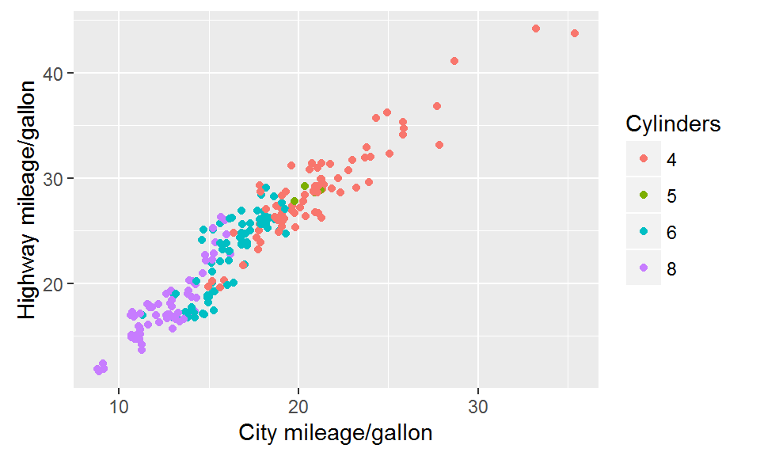

```r
mpg %>% ggplot( aes(x = cty, y = hwy, color = factor(cyl))) +
  geom_jitter() +
  labs(
    x = "City mileage/gallon",
    y = "Highway mileage/gallon",
    color = "Cylinders"
  )
```

Suppose we want to make the following modifications to this plot:

- change the default colors in the display
- increase the font size of the axis labels
- remove the minor grid lines on both axes
- add a plot title
- move the legend inside the graphics region
- change the background color of the graphics region

The first of these depends on the data itself, so we can use one of the `scale_colour_*()` functions for that purpose —see [ggplot2 help](http://docs.ggplot2.org/current/).

The others influence the rendering of the graphic but are independent of the data being plotted. These are called theme elements, i.e., aspects of a ggplot object that are capable of modifying its appearance but are neither directly related to data nor aesthetics associated with data.

```r
theme_grey()
```

[output not shown]

[output cut: 205 more lines]

[output not shown]

The output of this call lists the properties of a ggplot object that can be accessed by users along with their default values, expressed as a list of lists. The theme() function allows you to locally modify properties of theme elements in a ggplot object.

One way of implementing the desired changes listed above is as follows:

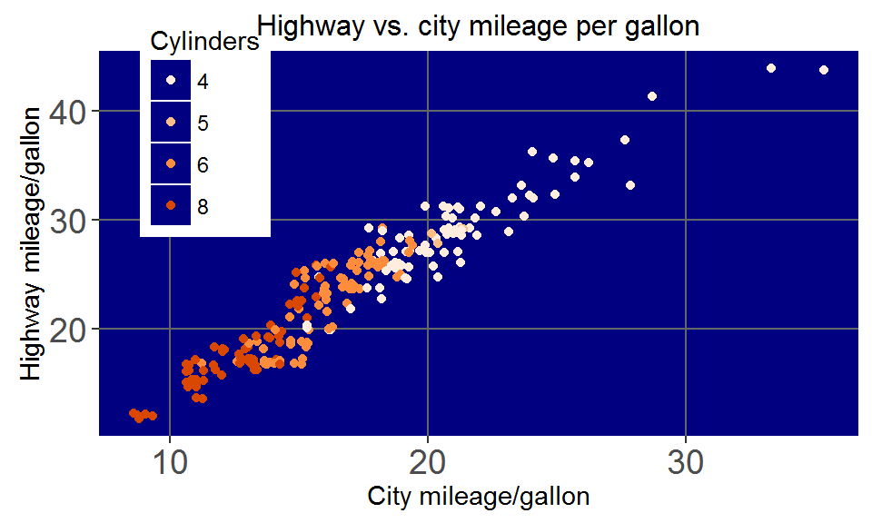

```r
p <- mpg %>% ggplot( aes(x = cty, y = hwy, colour = factor(cyl))) +
  geom_jitter() +
  labs(
    x = "City mileage/gallon",
    y = "Highway mileage/gallon",
    colour = "Cylinders"
  ) +
  scale_colour_brewer(type = "seq", palette = "Oranges")

# Use theme() to modify theme elements
p + labs(title = "Highway vs. city mileage per gallon") +
  theme(
    axis.text = element_text(size = 14),
    plot.title = element_text(size=12),
    legend.key = element_rect(fill = "navy"),
    legend.background = element_rect(fill = "white"),
    legend.position = c(0.14, 0.80),
    panel.grid.major = element_line(colour = "grey40"),
    panel.grid.minor = element_blank(),
    panel.background = element_rect(fill = "navy")
  )
```

The `element_xx()` functions modify theme elements with attributes (e.g., color, text size). Some theme elements are defined in terms of a unit of measurement, while others, such as legend.position, control the positioning of a theme element. These will be illustrated in greater detail in the examples to follow.

In the above call, `element_text()` modifies the size property of the `axis.text` theme element, `element_rect()` changes the fill color of the `legend.key`, `legend.background` and `panel.background` theme elements, `element_line()` alters the color of the major grid lines in both directions and `element_blank()` removes the minor grid lines from the display in both directions. Finally, the form of the `legend.position()` call moves the center of the legend grob to a position in coordinates relative to the size of the overall graphics device (not the graphics panel that delimits the graph itself). In this case, the default theme function is `theme_grey()`, so `theme()` locally changes the above settings in `theme_grey()` to the values specified in the call.

# Task for you:

Copy the previous chunk and make modifications to produce the following plot:

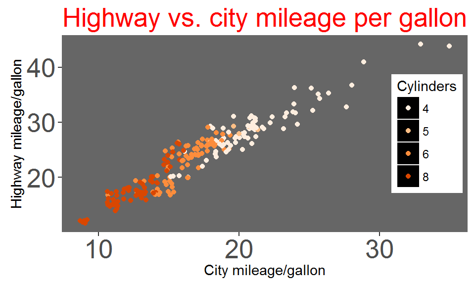

```r
p <- mpg %>% ggplot( aes(x = cty, y = hwy, colour = factor(cyl))) +
  geom_jitter() +
  labs(
    x = "City mileage/gallon",
    y = "Highway mileage/gallon",
    colour = "Cylinders"
  ) +
  scale_colour_brewer(type = "seq", palette = "Oranges")

# Use theme() to modify theme elements
p + labs(title = "Highway vs. city mileage per gallon") +
  theme(
    axis.text = element_text(size = 20),
    plot.title = element_text(size = 20,color = "red"),
    legend.key = element_rect(fill = "black"),
    legend.background = element_rect(fill = "white"),
    legend.position = c(.9,.5),
    panel.grid.major = element_blank(),
    panel.grid.minor = element_blank(),
    panel.background = element_rect(fill = "grey40")
  )
```

The default theme for *ggplot2* graphics is `theme_grey()`, but you can override it with another (complete) theme function. A second theme function built into the system is `theme_bw()`, which can be plugged in as a replacement for `theme_grey()` as follows:

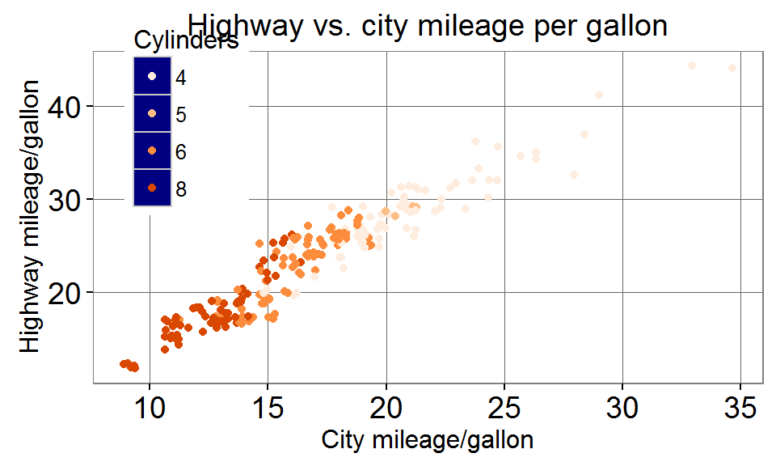

```r
p + labs(title = "Highway vs. city mileage per gallon") +
  theme_bw() +
  theme(axis.text = element_text(size = 14),
    legend.key = element_rect(fill = "navy"),
    legend.background = element_rect(fill = "white"),
    legend.position = c(0.14, 0.80),
    panel.grid.major = element_line(colour = "grey40"),
    panel.grid.minor = element_blank()
  )
```

Adding `theme_bw()` to the ggplot() call means that `theme_bw` becomes the default theme for the created ggplot object. The call `theme_bw()` produces a theme object which can be modified with `theme()`.